# **Data Analysis Project: 311 Service Requests**

### **Monthly Distribution of Complaints**

```python
# Grouping complaints by month and plotting their distribution
data['Month'] = data['Open Date'].dt.month
monthly_complaints = data.groupby('Month').size()
```

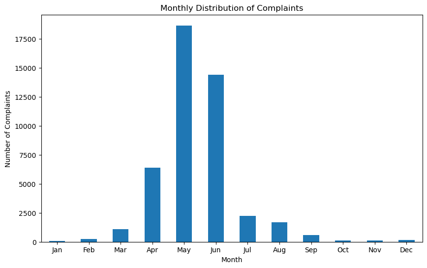

```python
plt.figure(figsize=(10, 6))
monthly_complaints.plot(kind='bar')
plt.title('Monthly Distribution of Complaints')
plt.xlabel('Month')
plt.ylabel('Number of Complaints')
plt.xticks(ticks=np.arange(12), labels=['Jan', 'Feb', 'Mar', 'Apr', 'May', 'Jun', 'Jul', 'Aug', 'Sep', 'Oct', 'Nov', 'Dec'], rotation=0)
plt.show()
```

**Results**: Seasonal Patterns: **May, June, and April** show the **highest complaint volumes**, which could be linked to specific seasonal factors (e.g., warmer weather leading to more outdoor activity, events, or seasonal problems like allergies).

Actionable Insight: These months may require additional resources or attention to handle the increased volume of complaints effectively.

### **Geographic Distribution of Complaints**

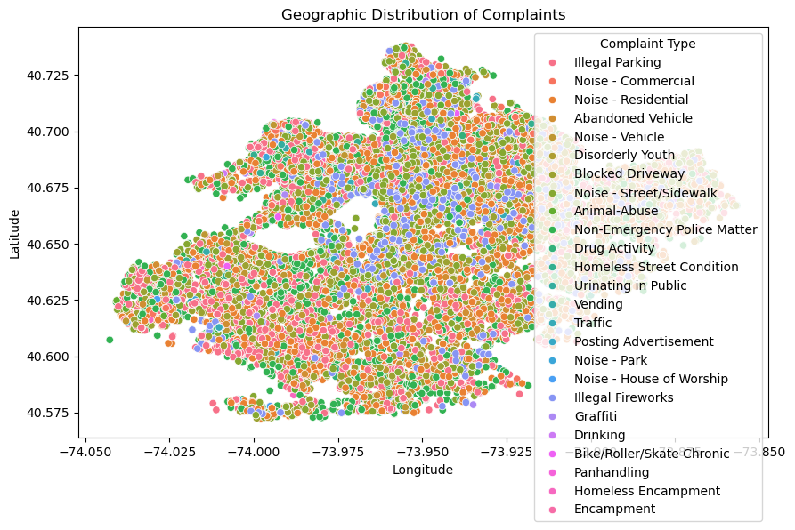

```python
# Scatter plot of complaints' geographic distribution (Longitude vs Latitude)
plt.figure(figsize=(10, 6))
sns.scatterplot(x='Longitude', y='Latitude', hue='Complaint Type', data=data)
plt.title('Geographic Distribution of Complaints')
plt.xlabel('Longitude')
plt.ylabel('Latitude')
plt.legend(title='Complaint Type')
plt.show()
```

**Explanation**: Visualized where complaints are concentrated geographically, categorized by complaint type.

### **Response Time Trend by Month**

```python
# Adding year and month columns
data['Year'] = data['Open Date'].dt.year
data['Month'] = data['Open Date'].dt.month
```

```python
# Grouping by year and month to analyze response time trends
monthly_response_time = data.groupby(['Year', 'Month'])['Response Time'].mean().reset_index()
```

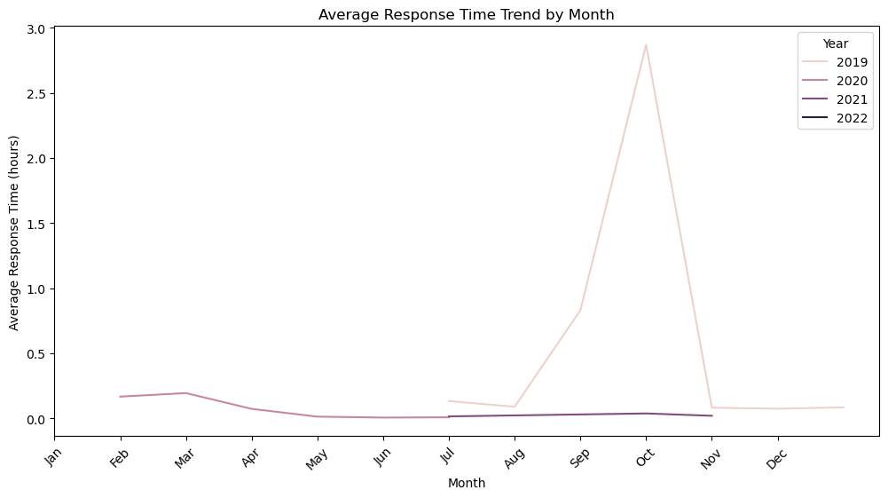

```python
# Plotting response time trend by month
plt.figure(figsize=(12, 6))
sns.lineplot(x='Month', y='Response Time', hue='Year', data=monthly_response_time)
plt.title('Average Response Time Trend by Month')
plt.xlabel('Month')
plt.ylabel('Average Response Time (hours)')
plt.xticks(np.arange(12), labels=['Jan', 'Feb', 'Mar', 'Apr', 'May', 'Jun', 'Jul', 'Aug', 'Sep', 'Oct', 'Nov', 'Dec'], rotation=45)
plt.legend(title='Year')
plt.show()
```

**Results**:

### **Average Resolution Time by Complaint Type**

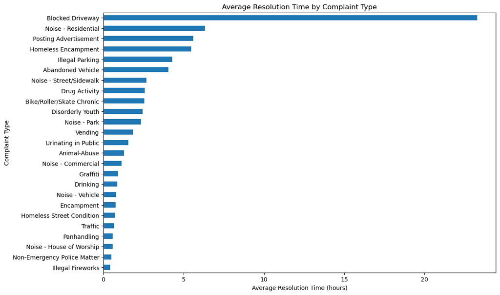

```python
# Calculating resolution time (in hours)
data['Resolution Time'] = (data['Closed Date'] - data['Open Date']).dt.total_seconds() / 3600

avg_resolution_time = data.groupby('Complaint Type')['Resolution Time'].mean().sort_values()

# Plotting average resolution time per complaint type
plt.figure(figsize=(12, 8))
avg_resolution_time.plot(kind='barh')
plt.title('Average Resolution Time by Complaint Type')
plt.xlabel('Average Resolution Time (hours)')
plt.ylabel('Complaint Type')
plt.show()
```

**Results**:

### **Correlation Matrix: Relationship Between Variables**

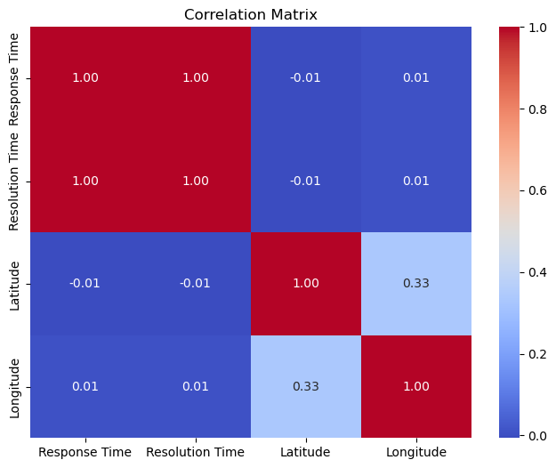

```python
# Correlation matrix for numerical columns
correlation_matrix = data[['Response Time', 'Resolution Time', 'Latitude', 'Longitude']].corr()

# Plot the correlation matrix
plt.figure(figsize=(8, 6))
sns.heatmap(correlation_matrix, annot=True, cmap='coolwarm', fmt='.2f')
plt.title('Correlation Matrix')
plt.show()
```

**Results**

- **Strong correlation**: Between **Response Time** and **Resolution Time** (1.00).
- **Moderate correlation**: Between **Latitude** and **Longitude** (0.33).
- **Weak correlation**: Response/Resolution Time with Latitude/Longitude (close to 0).

This matrix suggests that the **response/resolution times** are **independent** of geographic location, while **latitude and longitude** exhibit spatial dependence to some extent.

### **Density of Complainta by Location (Latitude and Longitude)**

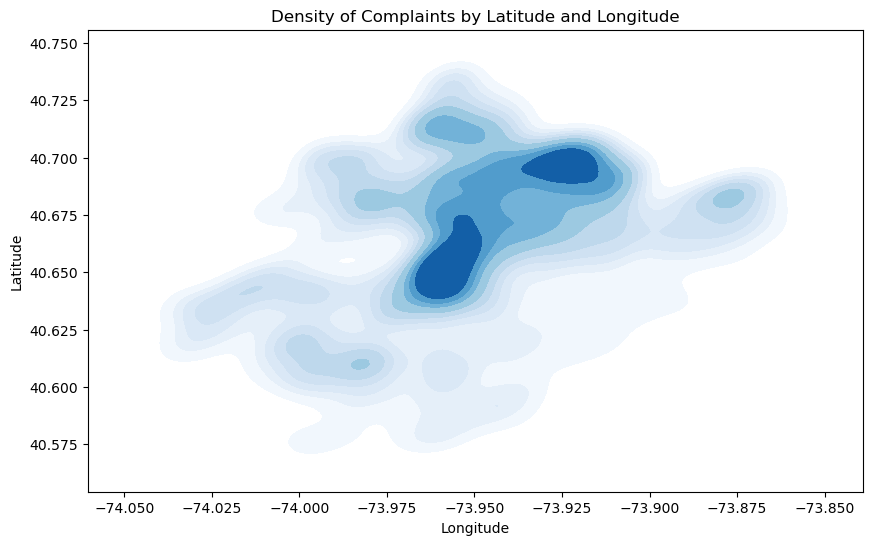

```python
plt.figure(figsize=(10, 6))
sns.kdeplot(x='Longitude', y='Latitude', data=data, fill=True, cmap='Blues')
plt.title('Density of Complaints by Latitude and Longitude')
plt.xlabel('Longitude')
plt.ylabel('Latitude')
plt.show()
```

**Results of Density Plot of Complaints**

- **High-Density Region**: The darker blue areas indicate **clusters with the highest concentration of complaints**, suggesting localized issues in specific regions (e.g., near latitude ~40.65, ~40.70 and longitude ~73.95, ~73.925 respectively).
- **Low-Density Spread**: Lighter shades of blue show areas with **lower complaint densities**, indicating sparse or minimal complaint occurrences.
- **Geographical Distribution**: Complaints are **not evenly distributed**; they are concentrated in specific zones, highlighting **hotspots** that may require further investigation or intervention.

### **Complaints by Hour of the Day**

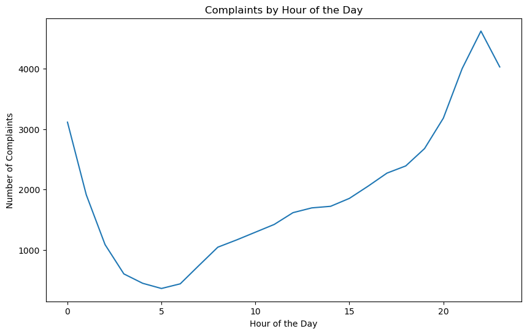

```python
# Extracting hour from Open Date
data['Hour'] = data['Open Date'].dt.hour

# Plotting complaints by hour of the day
plt.figure(figsize=(10, 6))
complaints_by_hour = data['Hour'].value_counts().sort_index()
sns.lineplot(x=complaints_by_hour.index, y=complaints_by_hour.values)
plt.title('Complaints by Hour of the Day')
plt.xlabel('Hour of the Day')
plt.ylabel('Number of Complaints')
plt.show()
```

### **Complaints Across Days of the Week**

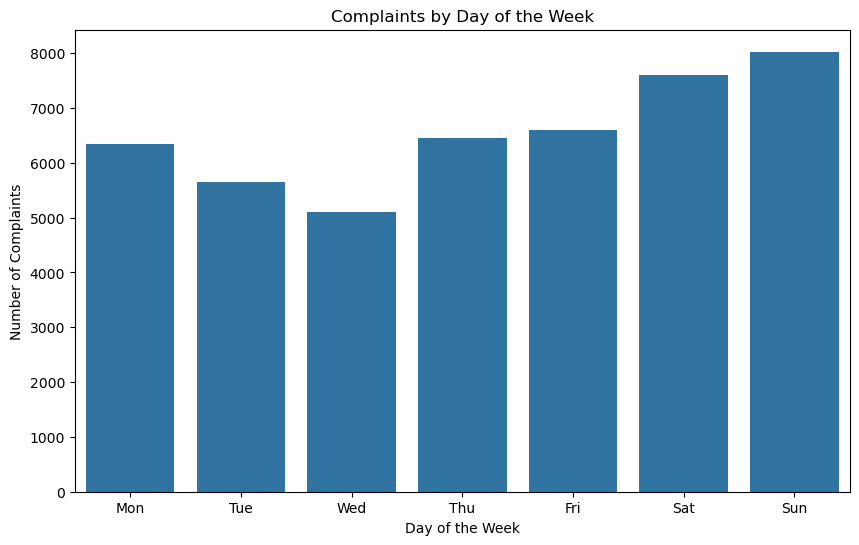

```python
# Extract day of the week from the Open Date (0=Monday, 6=Sunday)
data['Day of Week'] = data['Open Date'].dt.dayofweek

# Plot complaints by day of the week
plt.figure(figsize=(10, 6))
complaints_by_day = data['Day of Week'].value_counts().sort_index()
sns.barplot(x=complaints_by_day.index, y=complaints_by_day.values)
plt.title('Complaints by Day of the Week')
plt.xlabel('Day of the Week')
plt.ylabel('Number of Complaints')
plt.xticks(ticks=np.arange(7), labels=['Mon', 'Tue', 'Wed', 'Thu', 'Fri', 'Sat', 'Sun'], rotation=0)
plt.show()
```

**Results**

- **Weekend Peak**: Complaints are **highest on Saturday and Sunday**, with Sunday having the most (~8,000 complaints). This suggests increased reporting or activity during weekends.
- **Mid-Week Drop**: The number of complaints is lowest on **Wednesday** (~5,100), indicating reduced reporting or fewer issues mid-week.
- **Gradual Increase**: Complaints start increasing from Thursday onwards, peaking over the weekend, highlighting a trend of higher complaint activity toward the end of the week.

## **Conclusion for the Project**

1. **Key Findings**:
   - **Temporal Trends**: Complaints are highest during **evening hours** and on **weekends**, with Sunday recording the most complaints. This suggests that activity levels and free time influence complaint reporting.
   - **Spatial Distribution**: High-density complaint clusters were observed in specific geographic regions, indicating localized problem areas that require further investigation.
   - **Weak Correlation with Location**: Latitude and longitude show minimal correlation with response or resolution times, suggesting that location has little impact on these metrics.
2. **Insights**:
   - Patterns highlight that **time of day and day of the week** significantly impact complaint volumes, with evenings and weekends being peak periods.
   - Spatial hotspots could help focus resources in problematic areas, improving complaint resolution efficiency.
3. **Key Recommendations**
   - **Increase staff availability** during **evening hours (8 PM - 10 PM)** and **weekends** to handle peak complaint volumes.
   - **Focus on high-density geographic areas** to resolve recurring issues and improve service delivery.
   - **Implement user-friendly tools** with real-time tracking and automated status updates to streamline complaint handling.

By understanding temporal and spatial patterns, the analysis provides actionable insights for optimizing complaint handling and resource allocation.